# Lab 07 - Modelling earnings and course evaluations

Lizzy Goh

2026-11-13

### Packages and Data

```r
library(tidyverse)
library(tidymodels)
```

## Data set: college recent grads

```r
library(fivethirtyeight)
college_grad_df <- college_recent_grads
# First look at your data set
glimpse(college_grad_df)
```

```
## Rows: 173
## Columns: 21
## $ rank                        <int> 1, 2, 3, 4, 5, 6, 7, 8, 9, 10, 11, 12, 13,…
## $ major_code                  <int> 2419, 2416, 2415, 2417, 2405, 2418, 6202, …
## $ major                       <chr> "Petroleum Engineering", "Mining And Miner…
## $ major_category              <chr> "Engineering", "Engineering", "Engineering…
## $ total                       <int> 2339, 756, 856, 1258, 32260, 2573, 3777, 1…
## $ sample_size                 <int> 36, 7, 3, 16, 289, 17, 51, 10, 1029, 631, …
## $ men                         <int> 2057, 679, 725, 1123, 21239, 2200, 2110, 8…
## $ women                       <int> 282, 77, 131, 135, 11021, 373, 1667, 960, …
## $ sharewomen                  <dbl> 0.1205643, 0.1018519, 0.1530374, 0.1073132…
## $ employed                    <int> 1976, 640, 648, 758, 25694, 1857, 2912, 15…
## $ employed_fulltime           <int> 1849, 556, 558, 1069, 23170, 2038, 2924, 1…
## $ employed_parttime           <int> 270, 170, 133, 150, 5180, 264, 296, 553, 1…
## $ employed_fulltime_yearround <int> 1207, 388, 340, 692, 16697, 1449, 2482, 82…
## $ unemployed                  <int> 37, 85, 16, 40, 1672, 400, 308, 33, 4650, …
## $ unemployment_rate           <dbl> 0.018380527, 0.117241379, 0.024096386, 0.0…
## $ p25th                       <dbl> 95000, 55000, 50000, 43000, 50000, 50000, …
## $ median                      <dbl> 110000, 75000, 73000, 70000, 65000, 65000,…
## $ p75th                       <dbl> 125000, 90000, 105000, 80000, 75000, 10200…
## $ college_jobs                <int> 1534, 350, 456, 529, 18314, 1142, 1768, 97…
## $ non_college_jobs            <int> 364, 257, 176, 102, 4440, 657, 314, 500, 1…
## $ low_wage_jobs               <int> 193, 50, 0, 0, 972, 244, 259, 220, 3253, 3…
```

# Exercise 1: Exploratory Data Analysis

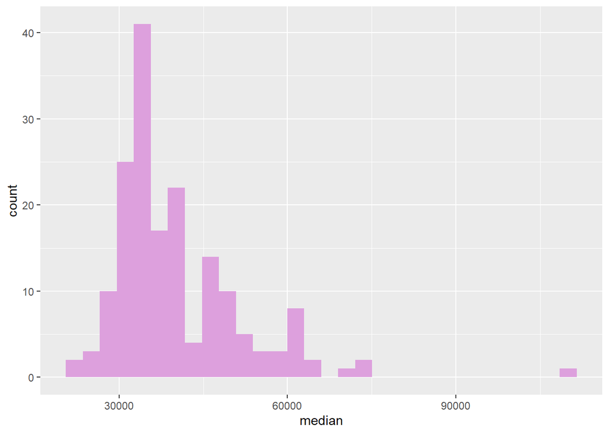

```r
college_grad_df %>% ggplot() +
  geom_histogram(aes(x= median), fill = "plum")
```

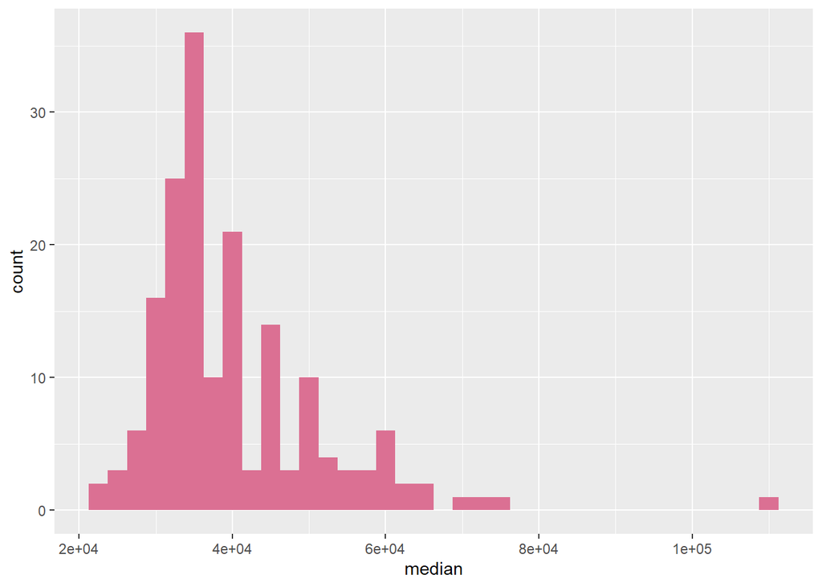

```r
college_grad_df %>% ggplot() +
  geom_histogram(aes(x= median), fill = "palevioletred", binwidth = 2500)
```

```r
college_grad_df %>%
  count(major_category, sort = TRUE)
```

```
## # A tibble: 16 × 2
##    major_category                          n
##    <chr>                               <int>
##  1 Engineering                            29
##  2 Education                              16
##  3 Humanities & Liberal Arts              15
##  4 Biology & Life Science                 14
##  5 Business                               13
##  6 Health                                 12
##  7 Computers & Mathematics                11
##  8 Agriculture & Natural Resources        10
##  9 Physical Sciences                      10
## 10 Psychology & Social Work                9
## 11 Social Science                          9
## 12 Arts                                    8
## 13 Industrial Arts & Consumer Services     7
## 14 Law & Public Policy                     5
## 15 Communications & Journalism             4
## 16 Interdisciplinary                       1
```

*With a bandwidth of 2500, the histogram provides greater detail as the specified bandwidth is smaller than the standard, resulting in more bars. Regardless, the model is right leaning, leading to a positive skew, the count peaking/concentrated around a median of 3.5e+04. It also seems like there is a potential outlier around 1.1e+05*

# Exercise 2: Exploring relationship

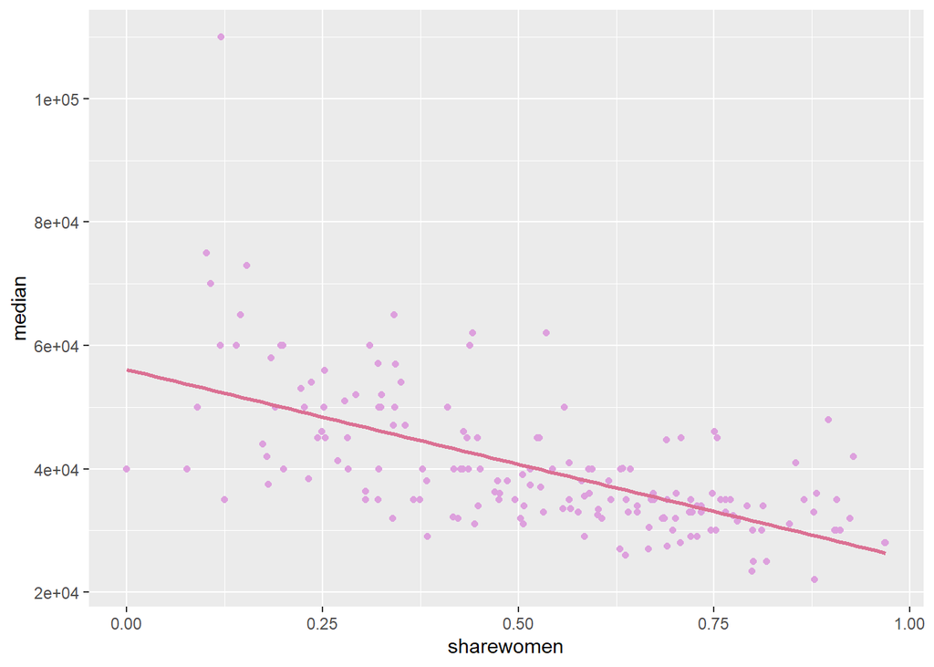

```r
college_grad_df %>% drop_na(sharewomen, median) %>%
  ggplot(aes(x = sharewomen, y= median)) +
  geom_point(colour = "plum") +
  geom_smooth(method = "lm", se = FALSE, colour = "palevioletred")
```

```r
coef(lm(median ~ sharewomen, data = college_grad_df))
```

```
## (Intercept)  sharewomen
##    56093.31   -30669.94
```

*From the scatter plot, there is a distinct negative correlation between a higher share of women and majors with lower median earnings, the formula of the line of best fit being: y = 56100 - 30700x, where y is median and x is sharewomen. Additionally, the negative gradient of -30700 indicates that for every 1 unit increase in the proportion of women, the predicted median earnings decrease by roughly $30,700.*

# Exercise 3: Fit and interpret a numerical predictor

```r
share_fit = linear_reg() %>%
  set_engine("lm") %>%
  fit(median ~ sharewomen, data = college_grad_df)

tidy(share_fit)
```

```
## # A tibble: 2 × 5
##   term        estimate std.error statistic  p.value
##   <chr>          <dbl>     <dbl>     <dbl>    <dbl>
## 1 (Intercept)   56093.     1705.      32.9 1.27e-75
## 2 sharewomen   -30670.     2987.     -10.3 1.51e-19
```

```r
glance(share_fit)
```

```
## # A tibble: 1 × 12
##   r.squared adj.r.squared sigma statistic  p.value    df logLik   AIC   BIC
##       <dbl>         <dbl> <dbl>     <dbl>    <dbl> <dbl>  <dbl> <dbl> <dbl>
## 1     0.383         0.379 9031.      105. 1.51e-19     1 -1810. 3625. 3635.
## # ℹ 3 more variables: deviance <dbl>, df.residual <int>, nobs <int>
```

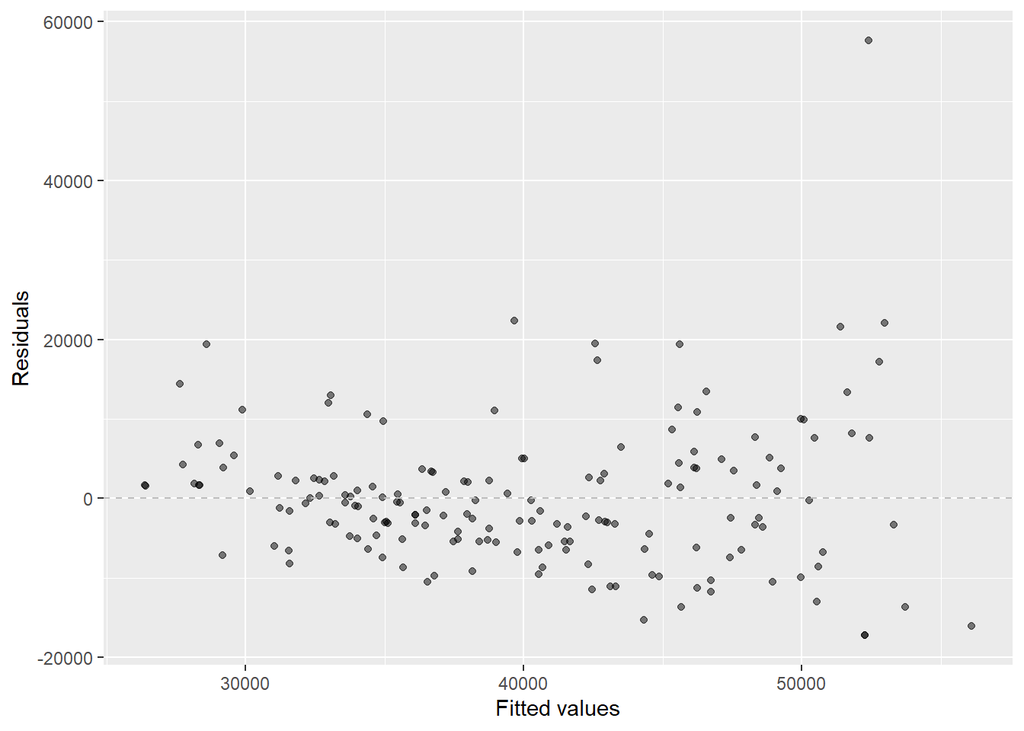

```r
share_fit_aug = augment(share_fit$fit)

share_fit_aug %>%
  ggplot(aes(x = .fitted, y = .resid)) +
  geom_point(alpha = 0.5) +
  geom_hline(yintercept = 0, color = "gray", lty = "dashed") +
  labs(x = "Fitted values", y = "Residuals")
```

*median = 56100 - 30700 sharewomen, is the formula of the fitted model. The negative gradient of -30700 indicates that for every 1 unit increase in the proportion of women, the predicted median earnings decrease by roughly $30,700 - just like the initial visualisation.*

*Doesn’t seem like there is a distinct trend or pattern, insinuating that a linear model may be suitable to model the data, however one could argue that the scatter plots fan out slightly at the end as the fitted values increase.*

# Exercise 4: Consider a categorical variable instead

```r
college_grad_df = college_grad_df %>% mutate(
  engineering = case_when(
    str_detect(major, regex("engineering", ignore_case = TRUE)) ~ "Engineering",
    TRUE ~ "Other"
  )
)

share_fit2 = linear_reg() %>%
  set_engine("lm") %>%
  fit(median ~ engineering, data = college_grad_df)

tidy(share_fit2)
```

```
## # A tibble: 2 × 5
##   term             estimate std.error statistic  p.value
##   <chr>               <dbl>     <dbl>     <dbl>    <dbl>
## 1 (Intercept)        58388.     1674.      34.9 1.13e-79
## 2 engineeringOther  -21463.     1816.     -11.8 5.96e-24
```

```r
glance(share_fit2)
```

```
## # A tibble: 1 × 12
##   r.squared adj.r.squared sigma statistic  p.value    df logLik   AIC   BIC
##       <dbl>         <dbl> <dbl>     <dbl>    <dbl> <dbl>  <dbl> <dbl> <dbl>
## 1     0.450         0.447 8534.      140. 5.96e-24     1 -1810. 3627. 3636.
## # ℹ 3 more variables: deviance <dbl>, df.residual <int>, nobs <int>
```

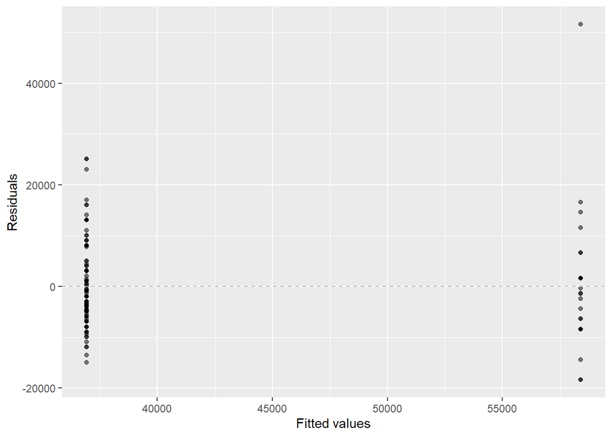

```r
share_fit2_aug = augment(share_fit2$fit)

share_fit2_aug %>%
  ggplot(aes(x = .fitted, y = .resid)) +
  geom_point(alpha = 0.5) +
  geom_hline(yintercept = 0, color = "gray", lty = "dashed") +
  labs(x = "Fitted values", y = "Residuals")
```

```r
levels(as.factor(college_grad_df$engineering))
```

```
## [1] "Engineering" "Other"
```

*The baseline category is Engineering. The intercept of 58,388.46 represents the average median earnings of Engineering majors, approximately $58,388.46. The slope of -21,462.61 indicates that Other majors have average median earnings approximately $21,462.61 lower than Engineering majors, giving them predicted average median earnings of $36,925.85.*

## Data set: Beauty in the classroom

```r
evals<-read.csv("data/evals.csv", row.names=1)
```

# Exercise 1: Exploratory Data Analysis

1. Visualize the distribution of `score` in the dataframe `evals`.

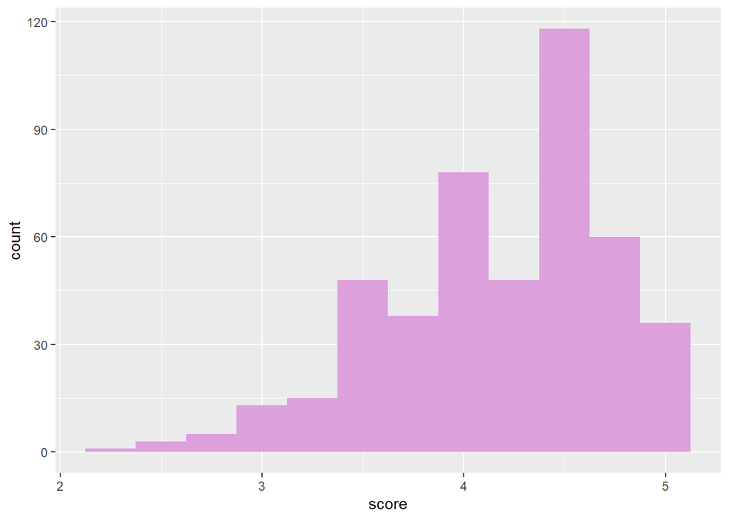

```r
evals %>%
  ggplot(aes(x = score)) +
  geom_histogram(binwidth = 0.25, fill = "plum")
```

```r
evals %>%
  summarise(
    mean = mean(score, na.rm = TRUE),
    median = median(score, na.rm = TRUE),
    sd = sd(score, na.rm = TRUE),
    min = min(score, na.rm = TRUE),
    max = max(score, na.rm = TRUE)
  )
```

```
##      mean median        sd min max
## 1 4.17473    4.3 0.5438645 2.3   5
```

*Model is left leaning, hence resulting in a negative skew showing that students generally rate courses higher.*

2. Visualize and describe the relationship between `score` and `bty_avg` using `geom_point()` to represent the data.

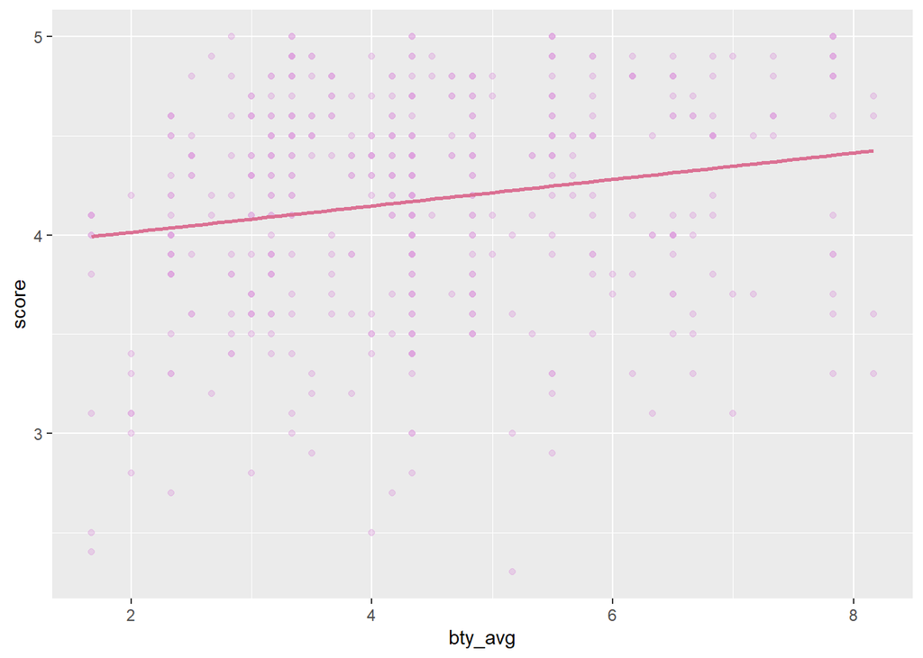

```r
evals %>% drop_na(score, bty_avg) %>%
  ggplot(aes(x = bty_avg, y= score)) +
  geom_point(colour = "plum", alpha = 0.4) +
  geom_smooth(method = "lm", se = FALSE, colour = "palevioletred")
```

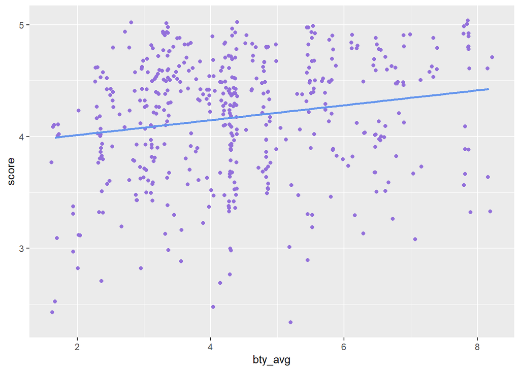

```r
evals %>% drop_na(score, bty_avg) %>%
  ggplot(aes(x = bty_avg, y= score)) +
  geom_jitter(colour = "mediumpurple") +
  geom_smooth(method = "lm", se = FALSE, colour = "cornflowerblue")
```

*Jitter adds small amount of noise. Multiple observations share identical bty_avg and score values. These observations overlap, making them appear as a single point. This creates the misleading impression that there are fewer observations in certain regions than there actually are. Jitter makes the density and frequency of observations easier to see.*

# Exercise 2: Simple Linear regression with a numerical predictor

1. Fit a linear model called `score_bty_fit` to predict average professor evaluation `score` from average beauty rating (`bty_avg`). Print the regression output using `tidy()`.

```r
# remove eval = FALSE from the code chunk options after filling in the blanks
score_bty_fit <- linear_reg() %>%
  set_engine("lm") %>%
  fit(score ~ bty_avg, data = evals)
```

```r
# remove eval = FALSE from the code chunk options after filling in the blanks
tidy(score_bty_fit)
```

```
## # A tibble: 2 × 5
##   term        estimate std.error statistic   p.value
##   <chr>          <dbl>     <dbl>     <dbl>     <dbl>
## 1 (Intercept)   3.88      0.0761     51.0  1.56e-191
## 2 bty_avg       0.0666    0.0163      4.09 5.08e-  5
```

*score = 3.880 + 0.067bty_avg.*

2. Plot the data again using `geom_jitter()`, and add the regression line.

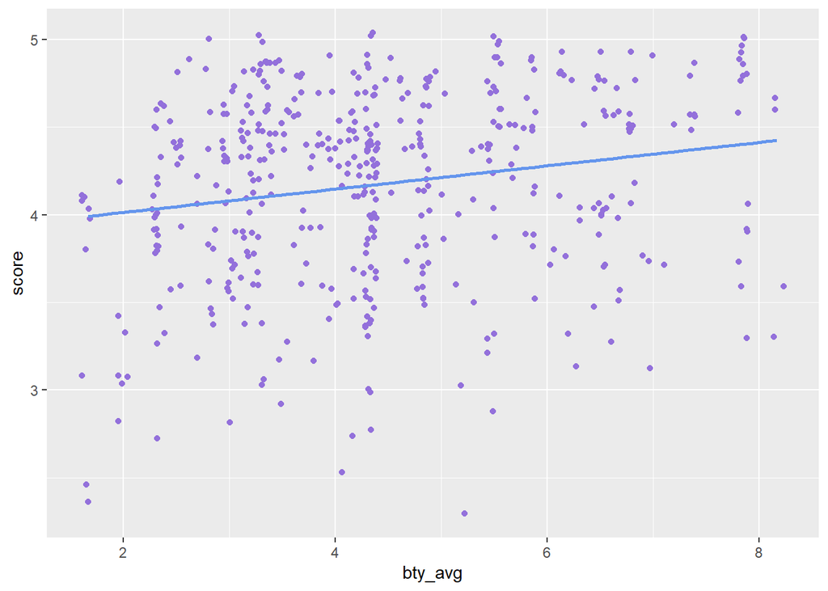

```r
evals %>% drop_na(score, bty_avg) %>%
  ggplot(aes(x = bty_avg, y= score)) +
  geom_jitter(colour = "mediumpurple") +
  geom_smooth(method = "lm", se = FALSE, colour = "cornflowerblue")
```

3. Interpret the slope of the linear model in context of the data.

*The gradient of the regression line tells you how much the predicted score changes for every 1-unit increase in bty_avg.*

4. Interpret the intercept of the linear model in context of the data. Comment on whether or not the intercept makes sense in this context.

*The model shows that as bty_avg increases, so does score. The intercept represents the predicted teaching score for a lecturer with an average beauty rating of 0.*

5. Determine the $R^2$ of the model and interpret it in the context of the data.

```r
# remove eval = FALSE from the code chunk options after filling in the blanks
glance(score_bty_fit)
```

```
## # A tibble: 1 × 12
##   r.squared adj.r.squared sigma statistic   p.value    df logLik   AIC   BIC
##       <dbl>         <dbl> <dbl>     <dbl>     <dbl> <dbl>  <dbl> <dbl> <dbl>
## 1    0.0350        0.0329 0.535      16.7 0.0000508     1  -366.  738.  751.
## # ℹ 3 more variables: deviance <dbl>, df.residual <int>, nobs <int>
```

*the r squared value is 0.03502226, representing the proportion of variation in score that is explained by the linear regression model using bty_avg.*

6. Make a plot of residuals vs. predicted values for the model above.

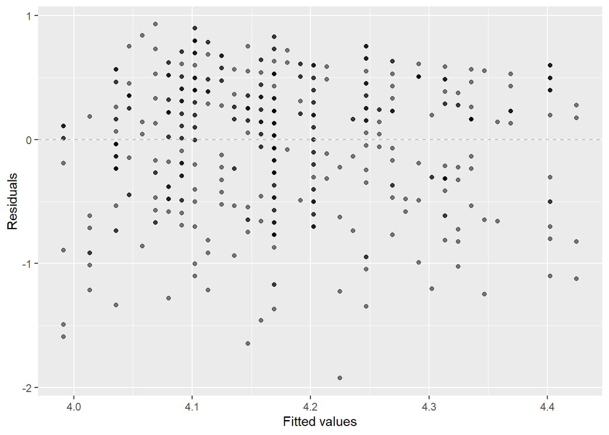

```r
# remove eval = FALSE from the code chunk options after filling in the blanks
score_bty_aug <- augment(score_bty_fit$fit)


score_bty_aug %>%
  ggplot(aes(x = .fitted, y = .resid)) +
  geom_point(alpha = 0.5) +
  geom_hline(yintercept = 0, color = "gray", lty = "dashed") +
  labs(x = "Fitted values", y = "Residuals")
```

# Exercise 3: Simple Linear regression with a categorical predictor

0. Look at the variable rank, and determine the frequency of each category level.

```r
count(evals, rank)
```

```
##           rank   n
## 1     teaching 102
## 2 tenure track 108
## 3      tenured 253
```

1. Fit a new linear model called `score_rank_fit` to predict average professor evaluation `score` based on `rank` of the professor.

```r
score_rank_fit = linear_reg() %>%
  set_engine("lm") %>%
  fit(score ~ rank, data = evals)

tidy(score_rank_fit)
```

```
## # A tibble: 3 × 5
##   term             estimate std.error statistic   p.value
##   <chr>               <dbl>     <dbl>     <dbl>     <dbl>
## 1 (Intercept)         4.28     0.0537     79.9  1.02e-271
## 2 ranktenure track   -0.130    0.0748     -1.73 8.37e-  2
## 3 ranktenured        -0.145    0.0636     -2.28 2.28e-  2
```

```r
glance(score_rank_fit)
```

```
## # A tibble: 1 × 12
##   r.squared adj.r.squared sigma statistic p.value    df logLik   AIC   BIC
##       <dbl>         <dbl> <dbl>     <dbl>   <dbl> <dbl>  <dbl> <dbl> <dbl>
## 1    0.0116       0.00733 0.542      2.71  0.0679     2  -372.  752.  768.
## # ℹ 3 more variables: deviance <dbl>, df.residual <int>, nobs <int>
```

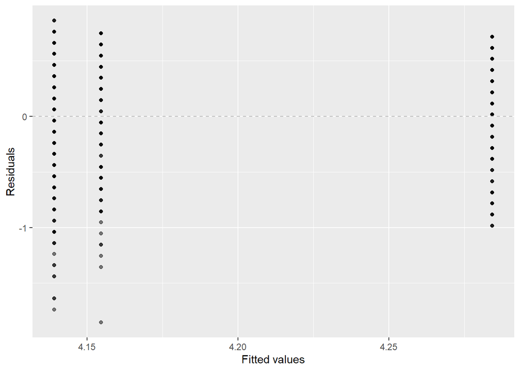

```r
score_rank_fit_aug = augment(score_rank_fit$fit)

score_rank_fit_aug %>%
  ggplot(aes(x = .fitted, y = .resid)) +
  geom_point(alpha = 0.5) +
  geom_hline(yintercept = 0, color = "gray", lty = "dashed") +
  labs(x = "Fitted values", y = "Residuals")
```

*No*

2. Fit a new linear model called `score_gender_fit` to predict average professor evaluation `score` based on `gender` of the professor.

```r
score_gender_fit = linear_reg() %>%
  set_engine("lm") %>%
  fit(score ~ gender, data = evals)

tidy(score_gender_fit)
```

```
## # A tibble: 2 × 5
##   term        estimate std.error statistic p.value
##   <chr>          <dbl>     <dbl>     <dbl>   <dbl>
## 1 (Intercept)    4.09     0.0387    106.   0
## 2 gendermale     0.142    0.0508      2.78 0.00558
```

```r
glance(score_gender_fit)
```

```
## # A tibble: 1 × 12
##   r.squared adj.r.squared sigma statistic p.value    df logLik   AIC   BIC
##       <dbl>         <dbl> <dbl>     <dbl>   <dbl> <dbl>  <dbl> <dbl> <dbl>
## 1    0.0165        0.0144 0.540      7.75 0.00558     1  -371.  747.  760.
## # ℹ 3 more variables: deviance <dbl>, df.residual <int>, nobs <int>
```

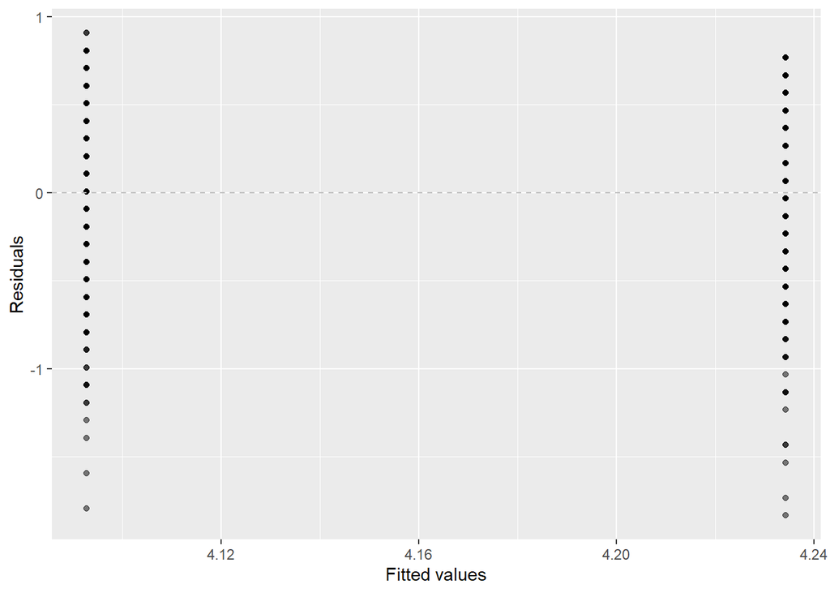

```r
score_gender_fit_aug = augment(score_gender_fit$fit)

score_gender_fit_aug %>%
  ggplot(aes(x = .fitted, y = .resid)) +
  geom_point(alpha = 0.5) +
  geom_hline(yintercept = 0, color = "gray", lty = "dashed") +
  labs(x = "Fitted values", y = "Residuals")
```

```r
# remove eval = FALSE from the code chunk options
score_gender_intercept <- tidy(score_gender_fit) %>%
  filter(term == "(Intercept)") %>%
  select(estimate) %>%
  pull()
```

```r
# remove eval = FALSE from the code chunk options
score_gender_slope <- tidy(score_gender_fit) %>%
  filter(term == "gendermale") %>%
  select(estimate) %>%
  pull()
```

# Exercise 4: Multiple linear regression

1. Fit a multiple linear regression model, predicting average professor evaluation `score` based on average beauty rating (`bty_avg`) and `gender.`

```r
score_bty_gender_fit = linear_reg() %>%
  set_engine("lm") %>%
  fit(score ~ bty_avg + gender, data = evals)

tidy(score_bty_gender_fit)
```

```
## # A tibble: 3 × 5
##   term        estimate std.error statistic   p.value
##   <chr>          <dbl>     <dbl>     <dbl>     <dbl>
## 1 (Intercept)   3.75      0.0847     44.3  6.23e-168
## 2 bty_avg       0.0742    0.0163      4.56 6.48e-  6
## 3 gendermale    0.172     0.0502      3.43 6.52e-  4
```

```r
glance(score_bty_gender_fit)
```

```
## # A tibble: 1 × 12
##   r.squared adj.r.squared sigma statistic     p.value    df logLik   AIC   BIC
##       <dbl>         <dbl> <dbl>     <dbl>       <dbl> <dbl>  <dbl> <dbl> <dbl>
## 1    0.0591        0.0550 0.529      14.5 0.000000818     2  -360.  729.  745.
## # ℹ 3 more variables: deviance <dbl>, df.residual <int>, nobs <int>
```

```r
levels(as.factor(evals$gender))
```

```
## [1] "female" "male"
```

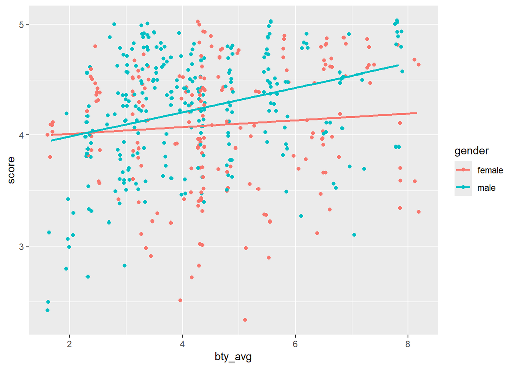

```r
evals %>%
  drop_na(score, bty_avg, gender) %>%
  ggplot(aes(x = bty_avg, y = score, colour = gender)) +
  geom_jitter() +
  geom_smooth(method = "lm", se = FALSE)
```

```r
coef(lm(score ~ bty_avg, data = evals))
```

```
## (Intercept)     bty_avg
##  3.88033795  0.06663704
```

```r
temp = evals %>% filter(gender == "female")

coef(lm(score ~ bty_avg, data = temp))
```

```
## (Intercept)     bty_avg
##  3.95005984  0.03064259
```

```r
temp = evals %>% filter(gender == "male")

coef(lm(score ~ bty_avg, data = temp))
```

```
## (Intercept)     bty_avg
##   3.7665508   0.1102611
```

2. What percent of the variability in `score` is explained by the model `score_bty_gender_fit`.

```r
glance(score_bty_gender_fit)
```

```
## # A tibble: 1 × 12
##   r.squared adj.r.squared sigma statistic     p.value    df logLik   AIC   BIC
##       <dbl>         <dbl> <dbl>     <dbl>       <dbl> <dbl>  <dbl> <dbl> <dbl>
## 1    0.0591        0.0550 0.529      14.5 0.000000818     2  -360.  729.  745.
## # ℹ 3 more variables: deviance <dbl>, df.residual <int>, nobs <int>
```

*5.9% of the variation in score is explained by the model - as shown by the r squared value.*

3. What is the equation of the line corresponding to just male professors?

4. For two professors who received the same beauty rating, which gender tends to have the higher course evaluation score?

*Depends on the score, higher the score, male teachers tend to have the higher course evaluation score, however for low scores, female teachers tend to have the higher course evaluation score.*

5. How does the relationship between beauty and evaluation score vary between male and female professors?

*Males have a steeper slope/gradient than the lobf for females, etc…*

6. How do the adjusted $R^2$ values of `score_bty_fit` and `score_bty_gender_fit` compare?

```r
# remove eval = FALSE from the code chunk options after filling in the blanks
glance(score_bty_fit)$adj.r.squared
```

```
## [1] 0.03292903
```

```r
glance(score_bty_gender_fit)$adj.r.squared
```

```
## [1] 0.05503202
```

*As the r squared value of score_bty_fit is 3.29% and score_bty_gender_fit is 5.50%, the model considering gender as well has a substantially larger percentage showing that the model can explain more of the variation of the the socre variable, hence showing that it is a more suitable/better model over the first model of score_bty_fit.*

7. Compare the slopes of `bty_avg` under the two models (`score_bty_fit` and `score_bty_gender_fit`).

*The gradient for score_bty_fit of 0.06663704, and for score_bty_gender_fit, the gradient is 0.07415537, showing that when considering gender as well, the gradient is steeper…*

# Exercise 5: Interpretation of log-transformed response variables

If you do not know how to use LaTeX, do this exercise with pen and paper.

*No*